# FVSpec：将真实世界的基于性质的测试转化为 Lean 挑战FVSpec: Real-World Property-Based Tests as Lean Challenges

Quinn Dougherty [†] Max von Hippel [†] Simon Henniger [†] Hazel Shackleton [†] Mike Dodds[4]

中英对照 · arXiv:2606.01008v4 · 2026 年 9 月 14 日Chinese–English edition · arXiv:2606.01008v4 · 14 September 2026

[arXiv](https://arxiv.org/abs/2606.01008v4)[PDF](https://arxiv.org/pdf/2606.01008v4)[HTML](https://arxiv.org/html/2606.01008v4)

## 摘要Abstract

随着 AI 系统生成的代码在全球代码总量中占据越来越大的比例，形式化验证提供了一种确保代码正确的原则性方法，而 AI 自身也可能承担其中的大部分验证工作。然而，我们尚不清楚，当今的模型和智能体在源自真实软件的验证任务上，表现究竟如何，因为现有基准大多依赖人工整理或合成的问题，或者关注数学而非程序验证。为弥补这一缺口，我们提出了一个用于评估 AI 在真实世界形式化软件验证任务上表现的基准。我们首先从真实的 Python 仓库中抓取了 7,413 个不同的基于性质的测试（PBT），随后自动将其中 2,623 个（35%）转换为 9,415 份带有 sorry 占位符的 Lean 4 规格，即每个 PBT $\approx$ 3.5 个形式化版本。将 PBT 转换为 Lean 规格具有挑战性：这需要在 Lean 中对 Python 建模，推断 PBT 所编码的性质，并处理副作用。我们介绍了一条将 PBT 转译为 Lean 的智能体流水线，评估了覆盖率和质量指标，并提供了使用多种方法生成证明的基线。全部代码，包括抓取器和智能体，以及全部数据，包括 PBT 和 Lean 规格，均已开源。As AI systems generate an ever-growing share of the world’s code, formal verification offers a principled way to ensure that code is correct, and AI itself may be able to shoulder much of the verification burden. Yet we lack a clear picture of how well today’s models and agents perform on verification tasks drawn from real-world software, since existing benchmarks rely largely on curated or synthetic problems, or focus on math rather than program verification. To close this gap, we present a benchmark for evaluating AI on real-world formal software verification tasks. We first scrape 7,413 distinct property-based tests (PBTs) from real-world Python repositories, then automatically translate 2,623 of them (35%) into 9,415 Lean 4 specifications with sorry placeholders ($\approx$3.5 formalizations/PBT). Translating PBTs to Lean specs is challenging: it requires modeling Python in Lean, inferring the property encoded in a PBT, and handling side effects. We describe an agentic pipeline for transpiling PBTs into Lean, evaluate coverage and quality metrics, and provide baselines for proof generation using several approaches. All code (scraper and agents) and data (PBTs and Lean specs) are open source.

## 1 引言1 Introduction

若干 AI 安全方案以通过形式化验证（FV）实施保障措施为前提，[1] 即利用能够生成并认证证明的软件系统（Dalrymple and Ammann, 2025；Dalrymple et al., 2024；von Hippel, 2026；Miyazono, 2024）。因此，软件验证是 AI 安全的一项关键目标；但目前，几乎没有证据表明 AI 能够自动完成验证。要实现这一点，我们首先需要高质量基准来开展训练。现有基准要么规模过小，例如 Loughridge et al.（2024）和 Ravi and Coblenz（2025）；要么关注数学而非软件验证，例如 Glazer et al.（2024）；要么源自专家主导的验证项目，例如 Chakraborty et al.（2025），不能反映典型软件项目中的任务。在真实软件上从零启动验证，比验证从第一天就为验证而构建的软件困难得多。例如，与后者不同，前者往往需要推理黑盒外部系统，以及多个不同组件之间的交互，而这些组件甚至可能采用不同的语言和架构（Buro et al., 2020；Perconti and Ahmed, 2014）。Several AI safety proposals are premised on implementing safeguards by way of *formal verification* (FV)[1] – that is, software systems that can produce and certify proofs (Dalrymple and Ammann, 2025; Dalrymple et al., 2024; von Hippel, 2026; Miyazono, 2024). Software verification is therefore a key goal for AI safety, yet, currently, there is little evidence that AI can automate verification. To achieve this, we would first need high-quality benchmarks on which to train. Existing benchmarks are too small (e.g. Loughridge et al. (2024), Ravi and Coblenz (2025)), focused on math rather than software verification (e.g. Glazer et al. (2024)), or derived from expert-driven verification projects (as in Chakraborty et al. (2025)) that do not reflect the tasks involved in a typical software project: bootstrapping verification in real-world software is much more challenging than verifying software which was built to be verified from day one. For instance, the former, unlike the latter, often requires reasoning about black-box external systems and the interactions of several different components, potentially in different languages and architectures (Buro et al., 2020; Perconti and Ahmed, 2014).

为反映真实世界验证的需求，我们提出了新基准 FVSpec，从公开的基于性质的测试（PBT）中提取验证挑战。PBT 是 FV 的“近亲”，已经得到广泛采用，有时也被称为“轻量级形式化方法”（Jackson and Wing, 1996）。在 FV 和 PBT 中，工程师都会编写规格，即软件必须满足的逻辑性质。例如，我们可以要求 Python 函数 isort(lst) 总是返回输入 lst 的一个有序排列。区别在于如何检查这个性质。在 FV 中，性质通过数学技术得到证明，从而带来近乎完全的可信度，但这需要高度专业的团队开展证明工程（Dodds, 2022），未来也许可以交由智能体完成。在 PBT 中，测试则根据看起来类似定理的一般规则随机生成。To reflect the needs of real-world verification, we propose a new benchmark, FVSpec, where we derive verification challenges from publicly available property-based tests (PBTs). PBT is a “close sibling” to FV which has seen significant adoption, sometimes called “lightweight formal methods” (Jackson and Wing, 1996). In both FV and PBT, engineers write *specifications*: logical properties that the software must obey. For example, we might require that a Python function isort(lst) always returns a sorted permutation of its input lst. The difference lies in how this property is checked. In FV, the property is proved using mathematical techniques, resulting in almost-perfect confidence, but requiring proof engineering by highly expert teams (Dodds, 2022) (or perhaps, in the future, agents). In PBT, tests are randomly generated based on general rules that look like theorems.

首先，我们抓取了 7,413 个使用 Python 的 Hypothesis 框架（MacIver et al., 2019）编写的不同 PBT，构成 FVSpec:PBT。每个 PBT 都可以看作作者希望证明或证伪的、关于某段代码的猜想。我们将代码和 PBT 转换为证明器 Lean 中的表达；Lean 正在成为 AI 验证领域事实上的标准。在转换过程中，每个 PBT 都成为一个猜想。我们将由此产生的猜想和代码语料称为 FVSpec:FV。猜想的 Lean 版本一旦得到证明，就成为定理。Dougherty and Mehta（2025）此前在 FVAPPS 中采用过类似方法。在 FVAPPS 中，源程序取自 APPS 基准（Hendrycks et al., 2021），随后由大语言模型推断规格，将其转换为 Hypothesis PBT，再提升为定理。我们将同一流程应用于真实环境中的 PBT。First, we scrape 7,413 distinct PBTs written in Python’s Hypothesis framework (MacIver et al., 2019), creating FVSpec:PBT. Each PBT can be seen as a conjecture about a piece of code, which the author would like to prove or disprove. We translate code and PBTs to the prover Lean, which is becoming the de-facto standard in AI verification. In the process of translation, each PBT becomes a conjecture. We refer to our resultant corpus of conjectures and code as FVSpec:FV. Once the Lean version of the conjecture is proven, it becomes a *theorem*. A similar approach was previously used by Dougherty and Mehta (2025) on FVAPPS. In FVAPPS, source programs were taken from the APPS benchmark (Hendrycks et al., 2021), then specs were inferred by an LLM and translated to Hypothesis PBTs, and then lifted to theorems. We apply the same process to PBTs found in the wild.

我们的主要贡献如下：Our main contributions are:

1. 1.

   FVSpec:PBT：从 497 个开源仓库中抓取并去重得到的 7,413 个 Python PBT，是首个源自普通软件开发的大型 PBT 数据集。[2]FVSpec:PBT — 7,413 deduplicated Python PBTs scraped from 497 open-source repositories, the first large PBT dataset drawn from ordinary software development[2].
2. 2.

   完整流水线 [3] 和数据集以 MIT/Apache 双重许可证开源发布。Open-source release of the full pipeline[3] and datasets under MIT/Apache dual license.

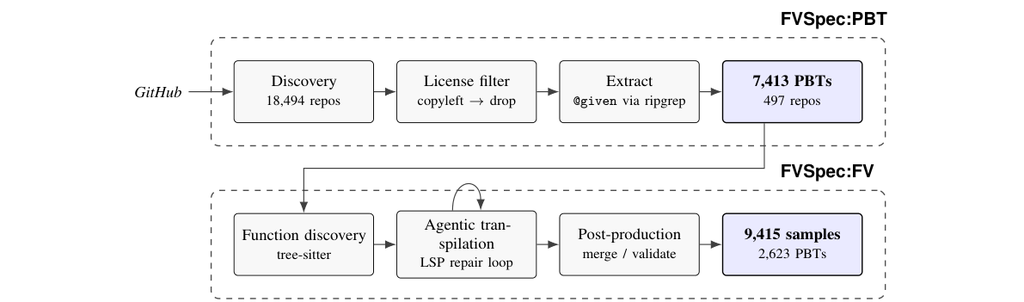

图 1：完整的 FVSpec 生成流水线，FVC 表示形式化验证挑战。上方为 FVSpec:PBT：从公开仓库抓取输入 PBT 语料。下方为 FVSpec:FV：通过基于 tree-sitter 的函数发现、带有 LSP 修复的智能体转译，以及验证、去重和评级的后处理，将每个 PBT 提升为 Lean 的（Impl, Spec）对；输入为 7,413 个 PBT，输出为 9,415 个 FVC，来自 2,623 个不同的 PBT。Figure 1: The full FVSpec generation pipeline (FVC = FV challenge). *Top* (FVSpec:PBT): the input PBT corpus is scraped from public repos. *Bottom* (FVSpec:FV): each PBT is lifted to a Lean (Impl, Spec) pair via tree-sitter–based function discovery, an agentic transpilation step (with LSP-repair), and a post-production step that validates, deduplicates, and grades the output; 7,413 PBTs enter and 9,415 FVCs (from 2,623 distinct PBTs) emerge.

## 2 任务定义2 Task Definition

每个问题由四部分组成：（1）原始的被测 Python 函数；（2）测试该函数的 PBT；（3）同一函数的 Lean 实现；（4）与 PBT 对应的 Lean 定理，在本应填写证明的位置保留 sorry 占位符。AI 的任务是为每个 sorry 填入一个 Lean 证明或反证，使其在 lake build 下顺利编译；之后，根据证明是否还保留 sorry 或专用公理进行评分。每个问题还包含指向原始代码的 URL 和许可证信息。我们以图 2 中的 isort(lst) 为贯穿示例。将 PBT 转换为 Lean 时，我们遇到了两个问题。Each problem consists of four components: (1) the original Python function under test and (2) PBT testing it, (3) a Lean implementation of the same function, and (4) a Lean theorem corresponding to the PBT, with a sorry placeholder where the proof should go. The AI’s task is to fill in every sorry with a Lean proof (or a disproof) that compiles cleanly under lake build; submissions are then scored by whether the proof retains any sorry or special-purpose axioms. Each problem also includes a URL pointing to the original code and license information. As a running example, consider isort(lst), illustrated in Figure 2. We encounter two issues when translating PBTs into Lean.

FVSpec:PBT

#### Python：isort 的实现Python: implementation of isort

```
from bisect import insort

def isort(lst):
    out = []
    for x in lst: insort(out, x)
    return out
```

#### Python：Hypothesis 基于性质的测试Python: Hypothesis PBT

```
from collections import Counter
from hypothesis import given
import hypothesis.strategies as st
@given(st.lists(st.integers()))
def test_isort(lst):
    out = isort(lst)
    pairs = zip(out, out[1:])
    assert all(a <= b for a, b in pairs)
    assert Counter(out) == Counter(lst)
```

FVSpec:FV

#### Lean：实现文件 Impl.leanLean: Impl.lean

```
namespace Fvspec.Impl

def insert (x : Int) : List Int -> List Int
  | []      => [x]
  | y :: ys => if x <= y then x :: y :: ys
               else y :: insert x ys

def isort : List Int -> List Int
  | []      => []
  | x :: xs => insert x (isort xs)

end Fvspec.Impl
```

#### Lean：规格文件 Spec.leanLean: Spec.lean

```
import Fvspec.Impl
open Fvspec.Impl

theorem isort_sorted (l : List Int) :
  (isort l).Sorted LE.le := sorry

theorem isort_perm (l : List Int) :
  (isort l).Perm l := sorry
```

图 2：每个问题分为两部分：左侧是 PBT 语料（FVSpec:PBT），即从 GitHub 抓取的原始 Python 实现及其 PBT；右侧是由其转译而来的形式化验证挑战（FVSpec:FV），即完整的 Lean 重新实现，以及对 PBT 进行一般化的定理陈述。AI 必须完成两个 Lean sorry 占位符，每个定理或其否定各对应一个。Figure 2: Each problem is partitioned into the *PBT corpus* (FVSpec:PBT, left)—the original Python implementation and PBT we scrape from GitHub—and the *formal-verification challenge* (FVSpec:FV, right) we transpile from it: a complete Lean re-implementation and theorem statement generalizing the PBT. The AI must discharge both Lean sorry placeholders, one per theorem (or negations).

##### 验证前的无意义定理。Nonsensical theorems pre-validation.

我们的流水线可能通过以下三种方式，生成形式良好但没有用处的陈述。Our pipeline can emit well-formed but useless statements in the following three ways.

（i）以 Unit 为返回类型的平凡猜想。当智能体无法恢复函数的返回类型时，会退回使用 Unit。由此产生的定理是一个重言式，例如 theorem isort_check : isort lst = () := by plausible。这个命题对任意返回 Unit 的全函数都成立，因此没有价值。Unit 出现在 Impl.lean 中被测函数的返回类型上，因而使猜想变得平凡。*(i) Trivial Unit-typed conjectures.* When the agent cannot recover a function’s return type, it falls back on Unit. The resulting theorem is a tautology—e.g. theorem isort_check : isort lst = () := by plausible, which holds for any total function into Unit and so carries no value. The Unit is on the function under test in Impl.lean, and the conjecture is trivial as a result.

（ii）类型错误或包含未解析符号的定理。智能体根据 Python 源代码，类比地编写 Lean。当它杜撰了不存在的 Lean 名称，例如写出 theorem isort_perm (l : List Int) : (isort l).permutationOf l := sorry，而 permutationOf 并不是 List 的成员，[4] 或者给出了与周围代码不一致的类型签名时，Lean 精化器会以 unknown identifier、type mismatch 等错误拒绝该文件。*(ii) Ill-typed or unresolved-symbol theorems.* The agent works from the Python source and writes Lean by analogy. When it invents a Lean name that does not exist—e.g., writing theorem isort_perm (l : List Int) : (isort l).permutationOf l := sorry, where permutationOf is not a member of List[4]—or attaches a type signature inconsistent with the surrounding code, the Lean elaborator rejects the file with errors like *unknown identifier*, *type mismatch*, etc.

（iii）规格定理泄漏到 Impl.lean 中。第一次运行时，我们分别使用智能体生成 Impl.lean 中的定义和 Spec.lean 中的定理。虽然实现智能体被明确要求不得生成定理，但它偶尔会抢先在 Impl.lean 中插入 namespace Fvspec.Spec … theorem isort_sorted … end Fvspec.Spec 代码块。这违反了文件分工；如果不删除，就会悄然扩大证明义务。*(iii) Spec theorems leaking into Impl.lean.* Our first run used separate agents for Impl.lean (definitions) and Spec.lean (theorems). The implementation agent is explicitly instructed to emit no theorems, but occasionally it pre-empts the spec agent by inserting a namespace Fvspec.Spec…theorem isort_sorted…end Fvspec.Spec block inside Impl.lean, which violates our file split and would silently expand the proof obligation if left in.

我们使用正则表达式检测（i），在编译时丢弃（ii），并通过能够识别命名空间的过滤器，移除 Impl.lean 中的 namespace Fvspec.Spec 块，以清除（iii）。仍有少量样本，占 0.7%，在 Impl.lean 的任何命名空间之外，带有独立的 theorem 声明。因为评分只针对 Spec.lean，这些声明不会扩大证明义务，但它们代表了逃过过滤器的零散证明活动。即使某个定理已经偏离原始 PBT，只要通过这三类过滤，它仍然是一个合理的挑战问题。We catch (i) by regex, drop (ii) at compile time, and strip (iii) with a namespace-aware filter that removes namespace Fvspec.Spec blocks found in Impl.lean. A small residual (0.7% of samples) carries naked theorem declarations in Impl.lean written outside any namespace; because grading targets only Spec.lean, these do not expand the proof obligation, but they represent stray proof activity that escaped the filter. A theorem that survives all three filters is a reasonable challenge problem even if it has drifted from the original PBT.

##### Lean 作为一个近乎完美的判定器。Lean as a (nearly) perfect oracle.

Lean 内核裁定正确性，这在性质上强于统计抽样。但面对对抗行为，它并非完美无缺：AI 可以通过改变问题来满足内核，例如加入公理、弱化假设，或者利用 Lean 中的漏洞（Gopinathan, 2026；von Hippel and Dougherty, 2026）。为使钻空子的行为可见，我们从两个维度对每份提交评分：二元 proved 标志，即文件能够通过 lake build 编译，而且所有原始 sorry 都已完成；以及部分得分，即已完成的原始 sorry 所占比例。我们还记录证明新引入的任何公理依赖，因为 AI 可能悄悄导入强公理，使目标变得平凡。我们目前不会因额外公理而自动判失败，但会报告它们，供审查者标记可疑解答。提交还可以通过独立的 leanprover/comparator（Lean FRO, 2026）内核重新检查。The Lean kernel arbitrates correctness, which is qualitatively stronger than statistical sampling. But it is not adversarially perfect: an AI can satisfy the kernel by *changing the question*—adding an axiom, weakening hypotheses, or exploiting a vulnerability in Lean (Gopinathan, 2026; von Hippel and Dougherty, 2026). To make gaming visible, every submission is scored on two axes: a binary *proved* flag (the file compiles under lake build *and* every original sorry has been discharged) and partial credit (fraction of original sorrys discharged). We additionally record any axiom dependencies the proof introduces, since an AI can trivialize a goal by quietly importing strong axioms; we do not currently auto-fail on extra axioms, but report them so reviewers can flag suspicious solutions. Submissions can additionally be re-checked through the independent leanprover/comparator Lean FRO (2026) kernel.

## 3 方法3 Methods

我们需要解决两个问题：第一，如何抓取真实世界的 PBT；第二，如何大规模地将 PBT 转换为 FV 挑战。We had to solve two problems: first, how to scrape real-world PBTs, and seecond, how to convert PBTs into FV challenges at scale.

### 3.1 抓取 PBT 语料3.1 Scraping the PBT Corpus

我们从公开的 GitHub 仓库中抓取真实世界的 PBT。为了识别有价值的仓库，我们考察依赖关系：如果一个包依赖广泛使用的 PBT 库 Hypothesis（MacIver et al., 2019），我们就对它感兴趣。抓取器分为三个阶段。（1）发现。使用 PyGitHub（Jacques et al., 2026）爬取 Hypothesis 的依赖图。（2）许可证检查。跳过明确采用非宽松许可证的仓库，例如 AGPL、GPL、LGPL、MPL，并将许可证字符串与仓库其他元数据一起记录；对于无法检测出许可证的仓库，记录为“unknown”。这样做是为了避免软件许可证妨碍基准在非学术环境中的使用。（3）提取。对每个接受的仓库进行浅克隆，通过 ripgrep 定位 PBT，并解析周围的 Python 代码，恢复其中调用的本地定义函数的传递闭包。一次持续 24 小时的运行，共得到 54,345 个 PBT。We scrape real-world PBTs from public GitHub repositories. To identify which repos are interesting to us, we consider dependencies: if a package depends on Hypothesis MacIver et al. (2019), a widely-used PBT library, it is of interest. Our scraper operates in three stages. *(1) Discovery.* We crawl the Hypothesis dependency graph using PyGitHub Jacques et al. (2026). *(2) Licensing.* We skip repos with an explicitly non-permissive license (e.g. AGPL, GPL, LGPL, MPL), and record the license string—including “unknown” for repositories with no detectable license—alongside the rest of each repository’s metadata. Our thinking here is to avoid software that is licensed in a way that would preempt using our benchmark in nonacademic environments. *(3) Extraction.* We shallow-clone each accepted repository, locate PBTs via ripgrep, and parse the surrounding Python to recover the transitive closure of locally-defined functions called therein. A 24-hour run produced 54,345 PBTs.

#### 3.1.1 去重3.1.1 Deduplication

这 54,345 个 PBT 中，大部分都是副本。第一轮按仓库去重：根据 URL 的末尾名称 [5] 对仓库分组，每组保留星标最多的仓库；对于其他仓库，如果某个测试在规范化空白后得到的 SHA-256 已经出现在保留仓库中，就将其删除。这样剩下 718 个仓库中的 28,073 个 PBT，但不同测试只有 8,314 个。大多数重复 PBT 来自 PyTorch：其 Hypothesis 测试套件的全部或部分内容，出现在至少 42 个仓库中，占全部 54,345 个 PBT 中的 39,386 个。这些仓库只有 24 个名为 pytorch，其余使用不相关的名称，如 amd/ZenDNN-pytorch 或 fathnd/homomorphic。副本来自不同 PyTorch 版本，包含 33 套不同的 PBT 集合，没有任何一个 PBT 出现在全部 42 个仓库中。其他项目也存在复制：去掉 PyTorch 副本后，剩余 14,959 个 PBT 中，只有 6,567 个不同 PBT。因此，我们改为仅按 PBT 内容去重：移除注释和空行、合并空白后，以 SHA-256 为键；每个键只保留一个规范副本，依次按照星标数、分叉数和行 ID 选择。得到的语料包含 8,314 个 PBT，来自 466 个 GitHub 用户拥有的 538 个仓库，覆盖 476 个项目名称。FVSpec:PBT 的公开版本包含 21,746 个按名称去重、且能够从全新克隆中重新提取依赖的 PBT，覆盖其中 7,413 个不同测试；我们也发布了按 PBT 去重的代码。Most of those 54,345 PBTs are copies. Our first pass deduplicated by repository: we grouped repos by the base name of their URL[5], kept the most-starred repo in each group, and dropped tests from the others whose whitespace-normalized SHA-256 appeared in the kept one. That left 28,073 PBTs across 718 repositories, but only 8,314 distinct tests. Most of the non-distinct PBTs came from PyTorch, whose Hypothesis suite appears, whole or in part, in at least 42 repositories holding 39,386 of the 54,345 PBTs. Only 24 of them are named pytorch; the rest have unrelated names such as amd/ZenDNN-pytorch or fathnd/homomorphic. The copies come from different PyTorch versions and carry 33 different sets of PBTs, with no PBT appearing in all 42. Other projects are copied too: without the PyTorch copies, the remaining 14,959 PBTs contain only 6,567 distinct PBTs. We therefore deduplicate on the PBT alone, keying on a SHA-256 of the PBT with comments and blank lines removed and whitespace collapsed, and keep one canonical copy per key, chosen by stars, then forks, then row id. The resulting corpus has 8,314 PBTs from 538 repos owned by 466 GitHub users, spanning 476 project names. The public release of FVSpec:PBT contains the 21,746 name-deduplicated PBTs whose dependencies we could re-extract from a fresh clone, covering 7,413 of the distinct tests, and we release code for the PBT-deduplication.

#### 3.1.2 多样性3.1.2 Diversity

对于抓取型基准，一个长期存在的担忧是来源过于集中。例如，SWE-bench（Jimenez et al., 2024）的全部 2,294 项任务，仅来自 12 个仓库；django 占 37%，前三个仓库 django、sympy 和 scikit-learn 合计占 64%。我们发布的语料分布广泛得多：来自 497 个仓库，没有任何一个仓库贡献超过 11.5% 的 PBT，前十个仓库合计占 30.8%；而且，这些仓库多数是没有星标的个人项目，而不是经过挑选的展示代码。PBT 的代码行数中位数只有 10 行，但所测试的项目代码，长度约为它自身的 $2.8\times$。A perennial concern with scraped benchmarks is concentration: SWE-bench Jimenez et al. (2024), for instance, draws all 2,294 of its tasks from just 12 repositories, with django supplying 37% and the top three (django, sympy, scikit-learn) supplying 64%. Our released corpus is far more spread out—it draws from 497 repositories, no single one of which contributes more than 11.5% of the PBTs and whose top ten together contribute 30.8%—and most of those repositories are unstarred personal projects rather than curated showcase code. The median PBT is just 10 LoC, but exercises around $2.8\times$ its own length in project code.

为展示数据集的多样性，可以看看从中均匀随机抽取十个仓库的结果：[6] flytekit，工作流 SDK；landlab，地表建模工具包；onnx-embedding，基于 ONNX 的嵌入库；ch-backup，ClickHouse 备份工具；logot，日志输出断言库；mlstacks，MLOps 基础设施配置工具；whenever，日期时间库；anls_star_metric，文档问答评估指标；jsondiff，JSON 差异比较库；sec-parser，SEC 申报文件解析器。总体而言，这代表了真实世界的软件工程，而不是学术练习或竞赛编程。To illustrate the diversity of our dataset, consider the result of drawing ten repositories from it uniformly at random:[6] flytekit (workflow SDK), landlab (earth-surface modelling toolkit), onnx-embedding (ONNX-backed embedding library), ch-backup (ClickHouse backup tool), logot (log-output assertion library), mlstacks (MLOps infrastructure provisioner), whenever (datetime library), anls_star_metric (document-QA evaluation metric), jsondiff (JSON diffing library), and sec-parser (SEC-filings parser). This is broadly representative of real-world software engineering, as opposed to academic or competitive programming.

图 3 汇总了整个语料的三项代码质量指标。源测试的复杂度跨度很大，从只有一个断言的平凡测试，到使用多种策略、测试复杂库 API 的测试。这种多样性直接继承自真实工程实践，而不是按难度人工筛选出来的。Figure 3 summarizes three code-quality metrics across the corpus. The source tests span a wide range of complexity, from trivial single-assertion tests to multi-strategy tests exercising complex library APIs—diversity inherited directly from real-world engineering practice and not curated for difficulty.

[figure not shown]

图 3：Python 源代码特征。使用 Radon（Lacchia, 2026）计算 7,413 个去重后 PBT 的代码质量指标。左图为代码行数；中图为圈复杂度，即函数中线性独立执行路径的数量，等于二元分支点数量加一（McCabe, 1976），值越高表示控制流越复杂；右图为可维护性指数，是由 Halstead 体积（Halstead, 1977）、圈复杂度和源代码行数组合而成的 0—100 分指标，值越高越易维护；100 分处的尖峰，是 Radon 对分数封顶造成的。Figure 3: Python source characteristics. Code-quality metrics for the 7,413 deduplicated PBTs, computed by Radon (Lacchia, 2026). *Left*: lines of code. *Center*: cyclomatic complexity—the number of linearly independent execution paths through the function, i.e. one plus the number of binary branch points (McCabe, 1976); higher values indicate more complex control flow. *Right*: maintainability index—a 0–100 composite of Halstead volume (Halstead, 1977), cyclomatic complexity, and source lines, where higher is more maintainable; the spike at 100 is an artefact of Radon capping the score.

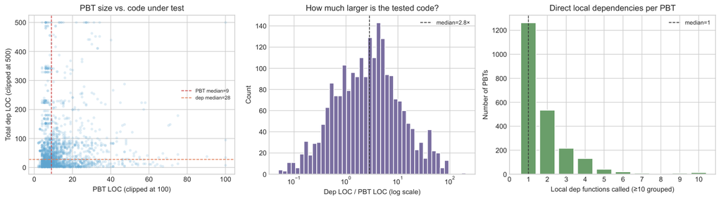

图 4：针对去重后能够恢复本地依赖的 $n=2{,}238$ 个 PBT，从三个角度展示 PBT 大小与被测代码大小之间的关系。其余 $5{,}175$ 个 PBT，要么只测试标准库或外部代码，要么依赖提取失败；因此，本图仅覆盖完整 $7{,}413$ 个 PBT 语料的一个子集。（a）每个 PBT 的代码行数与其直接调用依赖的总代码行数之间的散点图。（b）依赖代码行数与 PBT 代码行数之比的直方图，采用对数刻度；PBT 所测试代码长度的中位数，为其自身长度的 $2.8\times$。（c）每个 PBT 直接调用的本地函数数量的直方图。Figure 4: Three views of the relationship between PBT size and the size of the code being exercised, over the $n=2{,}238$ post-deduplication PBTs whose local dependencies were recoverable. (The remaining $5{,}175$ exercise only standard-library or external code, or had dependency extraction fail; the figure is therefore a subset of the full $7{,}413$-PBT corpus.) (a) Per-PBT scatter of PBT LoC against the total LoC of the directly-called dependencies. (b) Histogram of the ratio between dependency LoC and PBT LoC (log scale); the median PBT exercises code $2.8\times$ its own length. (c) Histogram of the number of direct local function calls per PBT.

### 3.2 将 PBT 转换为 Lean 挑战3.2 Turning PBTs into Lean challenges

我们分三个阶段，将语料 FVSpec:PBT 中的每个 PBT 提升为 Lean 的（Impl.lean, Spec.lean）对，见图 1 下方：函数发现、智能体转译和后处理。生成的挑战语料称为 FVSpec:FV。流水线以 FVAPPS（Dougherty and Mehta, 2025）为模型，但从 PBT 而非编程谜题出发，并增加了 LSP 修复。We lift each PBT in corpus (FVSpec:PBT) into a Lean (Impl.lean, Spec.lean) pair (Figure 1, bottom) in three phases: function discovery, agentic transpilation, and post-production. We call the resulting challenge corpus FVSpec:FV. The pipeline is modeled on FVAPPS (Dougherty and Mehta, 2025), except it starts from PBTs rather than programming puzzles, and adds LSP-repair.

函数发现。对于每个 PBT，我们使用 tree-sitter 提取被测函数，以及其本地依赖的传递闭包。较大的 PBT 会带入几十到几百行内部辅助函数。当发现失败时，通常是由于元类、装饰器或其他动态分派，我们会生成带有泛型类型参数的桩，使形式化智能体仍然能收到形式良好的输入。*Function discovery.* For each PBT we use tree-sitter to extract the function under test and the transitive closure of its local dependencies. Larger PBTs pull in tens to hundreds of lines of internal helpers. When discovery fails—typically due to metaclasses, decorators, or other dynamic dispatch—we emit a stub with generic type parameters so the formalization agent still receives well-formed input.

智能体转译。形式化智能体转换每个样本，同时生成 Impl.lean，即被测函数及其依赖的可计算移植版本，不含 sorry；以及 Spec.lean，即每个 Hypothesis 断言对应一个定理，证明保留为 sorry。每次生成后，我们通过 Lean LSP 对输出进行类型检查；若失败，就把编译器输出反馈给智能体。循环在成功时，或者固定预算耗尽时结束。第一次运行使用 claude-sonnet-4-5，发布了 5,979 个样本，实现和规格分别由不同智能体生成；第二次运行使用 claude-sonnet-4-6，生成 3,436 个样本。*Agentic transpilation.* A formalization agent translates each sample, producing both Impl.lean (a computable port of the function under test and its dependencies, no sorry) and Spec.lean (one theorem per Hypothesis assertion, with proofs left as sorry). After each generation step we type-check the output via the Lean LSP and, on failure, feed the compiler output back to the agent. The loop terminates on success or when a fixed budget runs out. The agents ran on claude-sonnet-4-5 in our first run (5,979 released samples), which used separate agents for the implementation and the specification, and on claude-sonnet-4-6 in our second run (3,436 samples).

后处理。首先，从形式化智能体生成的原始 .eval 文件归档中提取大语言模型交互轮数；该智能体作为 Inspect AI（UK AI Security Institute, 2024）任务运行。然后，将各次运行合并为一个 JSONL，按样本 ID 去重，并以质量评分打破并列；评分考虑结构忠实度、定理数量、单元测试和实现成功情况。接下来，对每个保留样本重新运行 lake build，丢弃失败样本，并将失败分为九类：超时、非良基递归、未知标识符、综合失败、类型不匹配、语法错误、缺失函数、函数应用错误和声明错误。之后，对 Lean 产物运行自定义 AST 分析器，提取代码行数、theorem 和 def 数量、剩余 sorry 及公理。最后，基于这些指标，使用 claude-haiku-4-5 作为评判器，赋予简单或困难的二元标签，同时给出置信分数和简短理由。[7]*Post-processing.* We first extract LLM turn counts from the raw .eval file archives produced by the formalization agent, which runs as an Inspect AI (UK AI Security Institute, 2024) task. We then collapse runs into a single JSONL, deduplicating by sample id and tie-breaking with a quality score (structural faithfulness, theorem count, unit-tests, implementation success). Next, we re-run lake build on each retained sample and drop failures, which we classify into nine families: timeouts, non-wellfounded recursion, unknown identifiers, failures to synthesize, type mismatches, syntax errors, missing functions, application errors, and declaration errors. We then run a custom AST analyzer on the Lean artifacts to extract line counts, theorem and def counts, residual sorry and axioms. Finally, conditioning on these metrics, we assign a binary easy/hard label using claude-haiku-4-5 as judge, together with a confidence score and a short rationale.[7]

副作用。一个特别的设计问题，是如何处理代码中的副作用。语料中的 PBT 来自复杂的真实环境：生产代码经常访问数据库、套接字、文件系统、实时时钟、Webhook 队列等。形式化智能体将带副作用的外部世界视为未解释接口，以此处理问题。源代码中对性质至关重要的部分，即性质所约束的实体和运算符，被转换为 Lean 结构体和归纳类型；纯粹承担连接职责的部分，如数据库、队列和系统时钟，则以不透明的公理声明引入，并作为参数贯穿定理。生成的定理对这些公理的所有解释都成立，而这恰好就是原始 PBT 在实际环境中所检查的契约。*Side effects.* A particular design issue is how to handle side effect in code. PBTs in our corpus come from messy real-world environments: production code routinely touches databases, sockets, the filesystem, the wall clock, webhook queues, and so forth. The formalization agent handles this by treating the effectful world as an *uninterpreted interface*. Parts of the source essential to the property—the entities and operators it constrains—are translated into Lean structures and inductive types. Parts that are pure plumbing—the database, the queue, the system clock—are introduced as opaque axiom declarations and threaded through the theorem as parameters. The resulting theorem holds *over all interpretations* of those axioms, which is exactly the contract the original PBT was checking against the live environment.

## 4 结果4 Results

FVSpec:FV 数据集流水线生成了 9,415 个样本，来自 2,772 个不同的 PBT：在 $7{,}413$ 个不同 PBT 中，成功形式化了 $2{,}623$ 个，占 $35\%$，见图 1 右下方；另外还有 149 个已经形式化的 PBT，无法追溯到当前公开版本。每个样本平均包含 8 个定理，中位数为 6，最大为 66；结构忠实度中位数为 0.65，见图 5。59% 的样本生成了完整的 Lean 实现；其余 41% 基于桩 Impl.lean 发布，因此定理陈述类型正确，但被约束的函数体是不透明的。Claude Haiku 评判器将数据集划分为 62% 的困难问题和 38% 的简单问题。如果同一个 PBT 产生多个能够编译的形式化版本，全部保留；is_canonical 字段标记每个 PBT 中质量最高的版本。Our pipeline for the FVSpec:FV dataset yields 9,415 samples drawn from 2,772 distinct PBTs: formalization succeeded for $2{,}623$ of $7{,}413$ distinct PBTs ($35\%$; Figure 1, bottom right); a further 149 formalized PBTs are not traceable to the current public release. The mean sample carries 8 theorems (median 6, max 66) and median structural faithfulness 0.65 (Figure 5). A complete Lean implementation was generated for 59% of samples; the remaining 41% ship against a stub Impl.lean, so the theorem statement is well-typed but the body it constrains is opaque. The Claude Haiku grader splits the dataset 62%/38% hard/easy. Where a PBT yields multiple compiling formalizations, all are kept; the is_canonical field marks the highest-quality version per PBT.

流水线独立地形式化 7,850 条原始 PBT 记录。按照内容将这些记录去重为 2,772 个唯一 PBT，见第 3.1.1 节，只合并 PBT，不合并其形式化版本，因此平均每个 PBT 保留 3.4 个形式化版本，范围为 1—15 个。在具有多个形式化版本的 PBT 中，32% 不存在一个全面占优的尝试：对于组中的每个形式化版本，总有另一个版本在忠实度指标的至少一个子指标上得分更高。在实践中，例如，断言覆盖率最高的尝试，其参数覆盖率可能不如同组另一个版本。因此，保留所有形式化版本，并用 is_canonical 标记最佳版本，严格来说，比只保留最高分尝试包含更多信息。The pipeline formalizes each of the 7,850 raw PBT records independently. Deduplicating those records onto 2,772 unique PBTs by content (Section 3.1.1) collapses the PBTs but not their formalizations, leaving a mean of 3.4 formalizations per PBT (range 1–15). Among PBTs with multiple formalizations, 32% have no single dominating attempt: for each formalization in the group there exists another that scores higher on at least one sub-metric of our faithfulness metric. In practice, this means for example, that the attempt with the best assertion coverage may have worse parameter coverage than a sibling; keeping all formalizations and flagging the best one with is_canonical therefore captures strictly more information than retaining only the top-scoring attempt.

### 4.1 转换质量4.1 Translation Quality

我们使用结构忠实度评估转换质量。具体来说，分别测量原始代码及其转换结果的五项子分数：参数覆盖率、类型对应程度、策略覆盖率、断言覆盖率和依赖覆盖率，并计算差异的加权平均值。图 5 展示了总体评分的分布，以及整个数据集上各子分数的均值。总体忠实度分布在 0.5 以上有一个明显众数，表明大多数转换保留了源 PBT 的关键结构，但仍存在较低质量转换形成的长尾。We evaluate translation quality using *structural faithfulness*. For this, we measure five sub-scores (parameter coverage, type correspondence, strategy coverage, assertion coverage, and dependency coverage) for both the original code and the translation, and we compute a weighted average of the difference. Figure 5 shows the distribution of the overall score and the mean of each sub-score across the dataset. The overall faithfulness distribution exhibits a clear mode above 0.5, indicating that the majority of translations preserve the essential structure of the source PBT, though a long tail of lower-quality translations remains.

[figure not shown]

（a）结构忠实度(a) Structural faithfulness

[figure not shown]

（b）难度评级(b) Difficulty grading

图 5：（a）结构忠实度：综合评分分布，左图，以及各子分数均值，右图。（b）难度评级：简单与困难问题的数量，左图，以及评判器置信度分布，右图。Figure 5: (a) Structural faithfulness: distribution of the composite score (left) and mean sub-scores (right). (b) Difficulty grading: easy vs. hard counts (left) and grader confidence distribution (right).

59% 的样本中，智能体生成了完整的 Lean 实现，即 Impl.lean 包含可计算定义；其余 41% 使用只有签名的占位实现。两组的结构忠实度相近，均值分别为 0.67 和 0.68，证实规格质量在很大程度上独立于实现恢复情况。生成的 Lean 产物，复杂度跨度很大，见图 6：中位样本包含多个定理，而且 sorry 数量与定理数量紧密对应。In 59% of samples the agent generated a complete Lean implementation (Impl.lean contains a computable definition); the remaining 41% use a signature-only placeholder. Structural faithfulness is comparable across both groups (mean 0.67 vs. 0.68), confirming that specification quality is largely independent of implementation recovery. The generated Lean artifacts span a wide range of complexity (Figure 6): the median contains multiple theorems, and the sorry count tracks the theorem count closely.

[figure not shown]

图 6：总代码行数，左图；每个样本的定理数，中图；每个样本的 sorry 占位符数量，右图。Figure 6: Total lines (left), theorems per sample (center), and sorry placeholders per sample (right).

### 4.2 难度评级4.2 Difficulty Grading

图 5 展示了难度评级结果，以及评判器置信度的分布。基准中，简单和困难问题都占有相当比例，而且评判器对大多数判断表达了较高置信度。这里，难度以预测的方式估计：我们要求评判器 haiku 预测，智能体是否能够完成证明。Figure 5 shows the results of our difficulty grading and the distribution of grader confidence. The benchmark contains a substantial proportion of both easy and hard problems, and the grader expresses high confidence for the majority of assessments. Difficulty is estimated here as a prediction, where we ask the grader (haiku) to predict whether or not an agent would be able to complete the proofs.

图 7 考察了难度与两项输出特征之间的关系：结构忠实度和 Lean 输出大小。困难问题往往产生更长的 Lean 输出，这与如下直觉一致：更复杂的源 PBT，会带来更复杂的形式化结果。Figure 7 examines the relationship between difficulty and two output characteristics: structural faithfulness and Lean output size. Hard problems tend to produce longer Lean outputs, consistent with the intuition that more complex source PBTs lead to more elaborate formalizations.

[figure not shown]

图 7：按难度分组的总体忠实度，左图，以及 Lean 总代码行数，右图。Figure 7: Overall faithfulness (left) and total Lean lines (right), stratified by difficulty.

### 4.3 基线4.3 Baselines

[figure not shown]

图 8：左图为按难度划分的至少一次证明成功率，即 best-of-k；右图为模型放弃的基线比例。Figure 8: Left: proved-ever rate by difficulty (best-of-k); right: baseline rate of the model giving up.

我们在随机抽取的 100 个简单问题和 100 个困难问题上，评估了三个前沿模型：Claude Sonnet 4.6、Opus 4.7 和 GPT 5.4。每个模型均可通过 MCP 工具访问 Lean LSP，并根据两个指标评分：二元 proved 标志，即没有剩余 sorry 且 lake build 成功；以及部分得分，即已移除 sorry 占位符的比例，并截断到 $[0,1]$ 区间。图 8 显示，这些模型平均解决了 49% 的困难样本和 70% 的简单样本。We evaluate three frontier models (Claude Sonnet 4.6, Opus 4.7, and GPT 5.4) on 100 randomly sampled easy problems and 100 hard problems. Each model has access to the Lean LSP via MCP tools and is scored on two metrics: a binary *proved* flag (zero sorry remaining and lake build succeeds) and *partial credit* (fraction of sorry placeholders removed, clamped to $[0,1]$). Figure 8 shows the models solved on average 49% of hard samples and 70% of easy ones.

## 5 局限性5 Limitations

规格通过转换生成，而非人工编写，因此部分规格可能无法忠实表达原始 PBT。我们的结构忠实度评分是一种启发式指标：高分并不保证语义等价，低分也不一定意味着问题没有用处。Specifications are translated rather than hand-written, so some may not faithfully represent the original PBT. Our structural-faithfulness score is a heuristic: a high score does not guarantee semantic equivalence, and a low score does not necessarily indicate a useless problem.

对于副作用的公理化处理，这一点尤其明显，而且存在一些具体局限。如果性质从根本上涉及时间、内存、副作用的顺序，或者实际时钟延迟，未解释公理就无法为它提供见证。assert response_time < 100ms 无法变成有意义的 Lean 定理，因为相关语义，恰恰就是公理化所丢弃的部分。此外，智能体通过类型签名和调用模式识别副作用边界。当一个函数具有纯函数式签名、内部却执行副作用时，例如通过全局对象调用日志记录器，或者具有 lru_cache 式隐藏状态，智能体会像处理纯函数一样将其内联。生成的定理可能能够编译，甚至可能为真，但不能保证其证明义务，始终对应原始代码真正要求的内容。This especially goes for our axiomatization approach to side effects, which has some specific limitations. If the property is fundamentally about timing, memory, ordering of side effects, or wall-clock latency, an uninterpreted axiom cannot witness it. assert response_time < 100ms cannot become a meaningful Lean theorem because the relevant semantics is precisely what the axiomatization discards. Also, the agent identifies effectful boundaries via type signatures and call patterns. When a function has a pure signature but performs side effects internally (e.g., a logger called via a global, an lru_cache-style hidden state), the agent will inline it as if pure. The resulting theorem may compile and even be true, but it is not guaranteed that its proof obligation always corresponds to what the original’s code would have been.

有些形式化版本的失真，无法被评分捕捉。样本 30，pbt_id 为 990，是来自 bjoern-reetz/cap-tools 的 test_alert_collection_holds_unrelated_alerts，忠实度为 0.75，被评为简单问题，定理也为真，但它错误地陈述了性质。AlertState 是一个字典，以每条警报的（sender, identifier, sent）引用为键，因此接收已有引用会覆盖该条目，而 UPDATE 和 CANCEL 消息会删除条目。Lean 版本却是一个只追加、不包含内容的警报列表，定理声称，对列表进行 ingest 折叠会返回该列表。智能体既没有看到真正的 AlertState，因为这个测试没有解析出任何依赖；也没有看到“引用从不碰撞”的前置条件，而测试的 Hypothesis 策略是在测试主体之外保证这一点的。忠实的陈述，需要一个带键的集合，以及关于引用的显式 Nodup 假设。依赖覆盖率是评分的一部分；只要没有解析出依赖，它就取 1.0。共有 3,793 个样本属于这种情况，占 40.3%。Some formalizations are unfaithful in ways the score does not catch. Sample 30 (pbt_id 990), test_alert_collection_holds_unrelated_alerts from bjoern-reetz/cap-tools, has faithfulness 0.75 and is graded easy, and its theorem is true, but it misstates the property. AlertState is a dictionary keyed by each alert’s (sender, identifier, sent) reference, so ingesting an existing reference overwrites that entry, and UPDATE and CANCEL messages delete entries. The Lean version is an append-only list of contentless alerts, and the theorem says that folding ingest over a list returns that list. The agent saw neither the real AlertState, because dependency resolution found nothing for this test, nor the precondition that references never collide, which the test’s Hypothesis strategy enforces outside the test body. A faithful statement needs a keyed collection and an explicit Nodup hypothesis on the references. Dependency coverage, one component of the score, is 1.0 whenever no dependencies are resolved, which is the case for 3,793 samples (40.3%).

我们的难度标签来自 claude-haiku-4-5，而模型自身的判断并不完美，也没有根据人类专家表现进行校准。我们公开每个样本的评判置信度和理由，让使用者能够审查或覆盖这些标签。Our difficulty labels come from claude-haiku-4-5, itself a model whose judgments are imperfect and uncalibrated against human expert performance. We expose the grader’s confidence and rationale per sample so consumers can audit or override the labels.

59% 的样本生成了完整的 Lean 实现；其余 41% 基于桩发布，削弱了证明义务：定理类型正确，但其约束的函数体不透明。这些样本已被标记，便于过滤。A complete Lean implementation is generated for 59% of samples; the remaining 41% ship against a stub, weakening the proof obligation: the theorem is well-typed but the body it constrains is opaque. These samples are tagged for easy filtering.

抓取器跳过明确采用非宽松许可证的仓库，但接受 GitHub 完全无法检测出许可证的仓库。Our scraper skips repositories with explicitly non-permissive licenses but accepts repositories where GitHub cannot detect a license at all.

我们没有测量人类专家在 FVSpec 问题上的表现，因此无法根据熟练人类所需的证明工作量，校准数据集难度。We do not measure human expert performance on FVSpec problems and therefore cannot calibrate the dataset’s difficulty against the proof effort required of skilled humans.

## 6 相关工作6 Related Work

我们的工作扩展了 FVAPPS（Dougherty and Mehta, 2025），后者确立了由 AI 驱动、将编程问题转换为 Lean 的方法。在 FVAPPS 中，程序来自 APPS 基准（Hendrycks et al., 2021），随后推断规格，将其实现为 PBT，再转译为 Lean 定理陈述。我们从自然语言和源代码推断规格，将同一流程大规模应用于真实环境中的 PBT。下文以及表 1 列出了相关工作。Our work extends FVAPPS (Dougherty and Mehta, 2025), which established AI-driven translation of coding problems into Lean. In FVAPPS, programs were taken from the APPS benchmark (Hendrycks et al., 2021), then specs were inferred and implemented as PBTs, then transpiled to Lean theorem statements. We apply the same process at scale to PBTs found in the wild, inferring specifications from natural language and source code. We enumerate related works below, and in Table 1.

Lean 验证基准。越来越多基准以 Lean 为目标。Lohn and Welleck（2024）提供了从 Tons of Inductive Programs 转换而来的 177 个程序规格，发现当前大语言模型无法处理中等和困难性质。Thakur et al.（2025）提供了来自 HumanEval 的 161 个精选问题，测试端到端的经验证代码生成。Wu et al.（2025b）在 189 项人工整理的编程任务上，覆盖了代码生成、规格生成和证明生成三项基础任务。Miranda et al.（2025）将带文档的 Python 代码转换为 Lean 实现、规格和单元测试，共 113 项任务。Bursuc et al.（2025）支持 Lean、Rust/Verus 和 Dafny，报告的成功率从 Lean 的 27% 到 Dafny 的 82% 不等。Zeng et al.（2026）使用 LeetCode 变换，在没有数据污染的新数据上评估可验证智能体。这些基准有价值，但有一个共同局限：它们的规格来自合成的编程问题或教学练习，而非一线工程师编写的性质。*Lean verification benchmarks.* A growing number of benchmarks target Lean. Lohn and Welleck (2024) provide 177 program specs translated from Tons of Inductive Programs, finding that current LLMs fail on medium and hard properties. Thakur et al. (2025) offer 161 curated problems sourced from HumanEval, testing end-to-end verified code generation. Wu et al. (2025b) cover all three foundational tasks—code generation, specification generation, and proof generation—across 189 manually curated coding tasks. Miranda et al. (2025) translate Python code with documentation into Lean implementations, specifications, and unit tests (113 tasks). Bursuc et al. (2025) support Lean, Rust/Verus, and Dafny, reporting success rates from 27% (Lean) to 82% (Dafny). Zeng et al. (2026) use LeetCode transformations to evaluate verifiable agents on novel data without contamination. These benchmarks are valuable but share a common limitation: their specifications derive from synthetic coding problems or pedagogical exercises, not from properties written by practicing engineers.

其他验证工具基准。Loughridge et al.（2024）提供 Dafny 验证任务。Beyer（2025）提供了软件验证器的标准竞赛，包含超过 33,000 项 C 语言任务，但面向的是自动化验证，而非交互式定理证明。[8] Wu et al.（2025a）专门关注循环不变式综合。Chakraborty et al.（2025）探索了 F* 中面向证明编程的神经综合，使用 SMT 辅助证明。*Other verification tool benchmarks.* Loughridge et al. (2024) provide Dafny verification tasks. Beyer (2025) provide the standard competition for software verifiers, with over 33,000 C tasks, but target automated verification rather than interactive theorem proving[8]. Wu et al. (2025a) focus specifically on loop invariant synthesis. Chakraborty et al. (2025) explore neural synthesis for SMT-assisted proof-oriented programming in F*.

交互式定理证明基准。Hsiang et al.（2025）提供了来自 Mathlib4 的 122,517 个定理。类似地，Thompson et al.（2024）从 GitHub 上的 2,226 个 Coq 仓库中收集了 196,929 个定理。这些定理主要面向数学，而不是软件，而且存在于大多数前沿模型的训练数据中。*Interactive theorem proving benchmarks.* Hsiang et al. (2025) provide 122,517 theorems from Mathlib4. Similarly, Thompson et al. (2024) collect 196,929 theorems from 2,226 GitHub Coq repositories. These are primarily mathematical rather than software-oriented, and their theorems exist in the training data of most frontier models.

数学基准。Glazer et al.（2024）评估高级数学推理。虽然 FV 和数学共享证明基础设施，但所需技能差别很大：软件验证要求对程序语义、库 API 和计算行为建模，而不是进行抽象数学推理。*Mathematics benchmarks.* Glazer et al. (2024) evaluatet advanced mathematical reasoning. Although FV and mathematics share proof infrastructure, the skills required differ substantially: software verification demands modeling of program semantics, library APIs, and computational behavior, rather than abstract mathematical reasoning.

FVSpec 与每一个现有基准，至少在以下三个方面之一存在区别。第一，规格来自一线工程师编写的真实 PBT，而不是合成问题或教学练习。第二，源 PBT 从未被形式化验证过，因此基准中的大多数定理，不会出现在任何模型的训练数据中。第三，相较于现有 Lean 验证基准，我们的规模更大，问题数量以千计，而不是以百计。我们的工作，其动机来自一个更广泛的背景：许多 AI 安全方案，以 AI 驱动的形式化验证为前提。FVSpec differs from each existing benchmark in at least one of the following three ways. First, our specifications originate from real-world property-based tests written by practicing engineers, not synthetic problems or pedagogical exercises. Second, the source PBTs were never formally verified, so most theorems in our benchmark will not appear in any model’s training data. Third, we operate at a larger scale than existing Lean verification benchmarks, with thousands rather than hundreds of problems. Our work is motivated by the broader context of AI safety proposals premised on AI-driven formal verification.

## 7 结论7 Conclusion

我们提出了 FVSpec：一个包含 9,415 项 Lean 4 形式化验证挑战的基准，源自从 497 个开源仓库抓取的 7,413 个不同的真实 Python PBT。此前的 FV 基准，往往来自专家编写的 ITP 代码、竞赛编程问题，或者人工整理的验证练习；与之不同，FVSpec 直接从没有形式化验证意图的一线工程师那里获取规格，使问题相对于模型训练数据真正处于分布之外。我们的智能体形式化流水线，从其中 2,623 个 PBT，即 35%，生成了 9,415 项挑战；结构忠实度中位数为 0.65，难度预测器将 62% 的挑战判为困难。对三个前沿模型的基线评估，证实该基准远未饱和，尤其在困难问题上，AI 辅助普通软件形式化验证，仍有很大进步空间。我们详细介绍的方法，可以很容易地扩展到其他语言的 PBT，例如 Haskell/QuickCheck、C++/RapidCheck、TypeScript/fast-check，以及其他 ITP，例如 Coq、Isabelle、F⋆ 和 Verus。其他潜在后续工作，包括与 HC-2026 语料合并以增加运行时上下文，以及利用被证伪的性质，作为程序修复挑战的种子：把原开发者测试框架遗漏的缺陷，在 Lean 中精确表达出来。We present FVSpec, a benchmark of 9,415 Lean 4 formal verification challenges derived from 7,413 distinct real-world Python property-based tests scraped from 497 open-source repositories. Unlike prior FV benchmarks—which draw from expert-written ITP code, competitive programming problems, or curated verification exercises—FVSpec sources its specifications directly from practicing engineers who had no formal verification intent, placing its problems genuinely out of distribution relative to models’ training data. Our agentic formalization pipeline produced 9,415 challenges from 2,623 of those PBTs (35%), with median structural faithfulness 0.65 and 62% of challenges classified as hard by a difficulty predictor. Baseline evaluations of three frontier models confirm that the benchmark is far from saturated, particularly on hard problems, leaving substantial room for progress on AI-assisted formal verification of ordinary software. Our approach, which we have described in depth, could easily be extended to PBTs from other languages (Haskell/QuickCheck, C++/RapidCheck, TypeScript/fast-check) and other ITPs (Coq, Isabelle, F<sup>⋆</sup>, Verus). Other potential future work includes merging with the HC-2026 corpus to add runtime context, and using disproved properties as seeds for program-repair challenges—bugs the original developer’s test harness missed, now made precise in Lean.

## 参考文献References

- Azerbayev et al. (2023) Z. Azerbayev, B. Piotrowski, H. Schoelkopf, E. W. Ayers, D. Radev, and J. Avigad ProofNet：自动形式化并形式化证明本科水平的数学Proofnet: autoformalizing and formally proving undergraduate-level mathematics. arXiv preprint arXiv:2302.12433. Cited by: Table 1.
- Bansal et al. (2019) K. Bansal, S. Loos, M. Rabe, C. Szegedy, and S. Wilcox HOList：面向高阶逻辑定理证明机器学习的环境Holist: an environment for machine learning of higher order logic theorem proving. In International conference on machine learning, pp. 454–463. Cited by: Table 1.
- Barkallah et al. (2025) S. Barkallah, S. Daruru, B. Miranda, L. Aniva, A. Nie, and S. Koyejo VeriBench-FTP：用于代码验证的 Lean 4 形式化定理证明基准VeriBench-FTP: a formal theorem proving benchmark in Lean 4 for code verification. In The 5th Workshop on Mathematical Reasoning and AI at NeurIPS 2025, Cited by: Table 1.
- Beyer (2025) D. Beyer 软件验证与见证验证的最新进展：SV-COMP 2025State of the art in software verification and witness validation: SV-COMP 2025. In Proceedings of the 31st International Conference on Tools and Algorithms for the Construction and Analysis of Systems (TACAS), Cited by: §6.
- Buro et al. (2020) S. Buro, R. Crole, and I. Mastroeni 多语言系统的等式逻辑与范畴语义Equational logic and categorical semantics for multi-languages. Electronic Notes in Theoretical Computer Science 352, pp. 79–103. Cited by: §1.
- Bursuc et al. (2025) S. Bursuc, T. Ehrenborg, S. Lin, L. Astefanoaei, I. E. Chiosa, J. Kukovec, A. Singh, O. Butterley, A. Bizid, Q. Dougherty, et al. Vericoding 基准：经过形式化验证的程序综合A benchmark for vericoding: formally verified program synthesis. arXiv preprint arXiv:2509.22908. Cited by: Table 1, §6.
- Chakraborty et al. (2025) S. Chakraborty, G. Ebner, S. Bhat, S. Fakhoury, S. Fatima, S. Lahiri, and N. Swamy 迈向 SMT 辅助的面向证明编程神经综合Towards neural synthesis for SMT-assisted proof-oriented programming. In Proceedings of the 47th International Conference on Software Engineering (ICSE), External Links: 2405.01787 Cited by: §1, §6.
- Dalrymple and Ammann (2025) D. Dalrymple and N. Ammann 具有保障机制的人工智能Safeguarded ai. ARIA. Note: https://aria.org.uk/opportunity-spaces/mathematics-for-safe-ai/safeguarded-ai/Accessed 25 April 2026 Cited by: §1.
- Dalrymple et al. (2024) D. Dalrymple, J. Skalse, Y. Bengio, S. Russell, M. Tegmark, S. Seshia, S. Omohundro, C. Szegedy, B. Goldhaber, N. Ammann, A. Abate, J. Halpern, C. Barrett, D. Zhao, T. Zhi-Xuan, J. Wing, and J. Tenenbaum 迈向有保证的安全 AI：确保 AI 系统稳健可靠的框架Towards guaranteed safe AI: a framework for ensuring robust and reliable AI systems. arXiv preprint arXiv:2405.06624. External Links: 2405.06624 Cited by: §1.
- DeVoe (2026) L. DeVoe Hypothesis 语料库The Hypothesis corpus. Note: https://hypothesis.works/articles/hypothesis-corpus/Accessed April 2026 Cited by: Table 3, Appendix B, footnote 2.
- Dodds (2022) M. Dodds 对工业界密码学进行形式化验证Formally verifying industry cryptography. IEEE Security & Privacy 20 (3), pp. 65–70. External Links: [Document](https://dx.doi.org/10.1109/MSEC.2022.3153035) Cited by: §1.
- Dougherty and Mehta (2025) Q. Dougherty and R. Mehta 证明编程面试题：形式化验证代码生成基准Proving the coding interview: a benchmark for formally verified code generation. In Proceedings of the LLM4Code Workshop at the 47th International Conference on Software Engineering (ICSE), Ottawa, Ontario, Canada. External Links: 2502.05714, [Document](https://dx.doi.org/10.48550/arXiv.2502.05714) Cited by: Table 1, §1, §3.2, §6.
- Glazer et al. (2024) E. Glazer, E. Erdil, T. Besiroglu, D. Chicharro, E. Chen, A. Gunning, C. Falkman Olsson, J. Denain, A. Ho, E. de Oliveira Santos, O. Järviniemi, M. Barnett, R. Sandler, M. Vrzala, J. Sevilla, Q. Ren, E. Pratt, L. Levine, G. Barkley, N. Stewart, B. Grechuk, T. Grechuk, S. Varma Enugandla, and M. Wildon FrontierMath：评估 AI 高级数学推理的基准FrontierMath: a benchmark for evaluating advanced mathematical reasoning in AI. arXiv preprint arXiv:2411.04872. External Links: 2411.04872 Cited by: §1, §6.
- Gopinathan (2026) K. Gopinathan Lean 证明了这个程序正确；随后我发现了一个缺陷Lean proved this program was correct; then I found a bug. Note: https://kirancodes.me/posts/log-who-watches-the-watchers.htmlBlog post; reports a heap buffer overflow in lean_alloc_sarray in the Lean 4 runtime, found by AFL++ fuzzing of the verified lean-zip library. Accessed 26 April 2026. Cited by: §2.
- Halstead (1977) M. H. Halstead 软件科学基础：操作与编程系统丛书Elements of software science (operating and programming systems series). Elsevier Science Inc.. Cited by: Figure 3.
- Hendrycks et al. (2021) D. Hendrycks, S. Basart, S. Kadavath, M. Mazeika, A. Arora, E. Guo, C. Burns, S. Puranik, H. He, D. Song, and J. Steinhardt 使用 APPS 衡量编程挑战能力Measuring coding challenge competence with APPS. In Proceedings of the 35th Conference on Neural Information Processing Systems (NeurIPS), External Links: 2105.09938 Cited by: §1, §6.
- Hsiang et al. (2025) R. Hsiang, W. Adkisson, R. J. George, and A. Anandkumar LeanDojo-v2：用于 Lean 中 AI 辅助定理证明的综合库LeanDojo-v2: a comprehensive library for AI-assisted theorem proving in Lean. In The 5th Workshop on Mathematical Reasoning and AI at NeurIPS 2025, Cited by: §6.
- Hu et al. (2024) J. Hu, T. Zhu, and S. Welleck MiniCTX：利用长上下文的神经定理证明MiniCTX: neural theorem proving with (long-) contexts. arXiv preprint arXiv:2408.03350. Cited by: Table 1.
- Huang et al. (2024) Y. Huang, X. Lin, Z. Liu, Q. Cao, H. Xin, H. Wang, Z. Li, L. Song, and X. Liang MUSTARD：掌握定理与证明数据的统一综合Mustard: mastering uniform synthesis of theorem and proof data. arXiv preprint arXiv:2402.08957. Cited by: Table 1.
- Jackson and Wing (1996) D. Jackson and J. M. Wing 轻量级形式化方法Lightweight formal methods. IEEE Computer 29 (4), pp. 21–22. External Links: [Document](https://dx.doi.org/10.1109/2.491459) Cited by: §1.
- Jacques et al. (2026) V. Jacques, L. Wan, S. Kowalik, and E. Minack PyGitHubPyGitHub. Note: https://github.com/PyGithub/PyGithubAccessed 26 April 2026 Cited by: §3.1.
- Jiang et al. (2025) J. Jiang, W. He, Y. Wang, G. Gao, Y. Hu, J. Wang, N. Guan, P. Wu, C. Dai, L. Xiao, and B. Dong FATE：涵盖多种难度的前沿代数形式化基准系列FATE: a formal benchmark series for frontier algebra of multiple difficulty levels. arXiv preprint arXiv:2511.02872. Cited by: Table 1.
- Jimenez et al. (2024) C. E. Jimenez, J. Yang, A. Wettig, S. Yao, K. Pei, O. Press, and K. Narasimhan SWE-bench：语言模型能否解决真实世界的 GitHub 问题？SWE-bench: can language models resolve real-world GitHub issues?. In Proceedings of the 12th International Conference on Learning Representations (ICLR), External Links: 2310.06770 Cited by: §3.1.2.
- Lacchia (2026) M. Lacchia Radon：Python 代码度量Radon: python code metrics. Note: https://radon.readthedocs.io/en/latest/ Cited by: Figure 3.
- Lean FRO (2026) Lean FRO Comparator：可信的 Lean 证明判定器Comparator: a trustworthy judge for Lean proofs. Note: https://github.com/leanprover/comparatorSandboxes the build and replays proof terms, optionally cross-checking against an independently-implemented Rust kernel (nanoda). Accessed 26 April 2026. Cited by: §2.
- Li et al. (2025) S. Li, W. Lu, X. Shi, K. Weng, H. Sun, M. Yu, T. Zhang, G. Yu, H. Liu, and L. Du MSC-180：基于数学主题分类的自动形式化定理证明基准MSC-180: a benchmark for automated formal theorem proving from mathematical subject classification. arXiv preprint arXiv:2512.18256. Cited by: Table 1.
- Liu et al. (2023) C. Liu, J. Shen, H. Xin, Z. Liu, Y. Yuan, H. Wang, W. Ju, C. Zheng, Y. Yin, L. Li, et al. Fimo：用于自动定理证明的挑战性形式化数据集Fimo: a challenge formal dataset for automated theorem proving. arXiv preprint arXiv:2309.04295. Cited by: Table 1.
- Lohn and Welleck (2024) E. Lohn and S. Welleck miniCodeProps：证明代码性质的最小基准miniCodeProps: a minimal benchmark for proving code properties. arXiv preprint arXiv:2406.11915. External Links: 2406.11915 Cited by: §6.
- Loughridge et al. (2024) C. Loughridge, Q. Sun, S. Ahrenbach, F. Cassano, C. Sun, Y. Sheng, A. Mudide, M. R. H. Misu, N. Amin, and M. Tegmark DafnyBench：形式化软件验证基准DafnyBench: a benchmark for formal software verification. arXiv preprint arXiv:2406.08467. External Links: 2406.08467 Cited by: Table 1, §1, §6.
- Lu et al. (2024) J. Lu, Y. Wan, Z. Liu, Y. Huang, J. Xiong, C. Liu, J. Shen, H. Jin, J. Zhang, H. Wang, et al. Lean 4 中流程驱动的自动形式化Process-driven autoformalization in lean 4. arXiv preprint arXiv:2406.01940. Cited by: Table 1.
- Lu et al. (2025) P. Lu, J. Sheng, L. Lyu, J. Jin, T. Xia, A. Gu, and J. Zou 使用大语言模型解决不等式证明Solving inequality proofs with large language models. In The 39th Conference on Neural Information Processing Systems (NeurIPS), Cited by: Table 1.
- MacIver et al. (2019) D. R. MacIver, Z. Hatfield-Dodds, and many other contributors Hypothesis：基于性质的测试的新方法Hypothesis: a new approach to property-based testing. Journal of Open Source Software 4 (43), pp. 1891. External Links: [Document](https://dx.doi.org/10.21105/joss.01891) Cited by: §1, §3.1.
- McCabe (1976) T. J. McCabe 一种复杂度度量A complexity measure. IEEE Transactions on Software Engineering (4), pp. 308–320. Cited by: Figure 3.
- Miranda et al. (2025) B. Miranda, S. Daruru, Z. Zhou, S. Barkallah, A. Nie, I. Mlauzi, L. Aniva, E. Obbad, W. Kirk, Y. Li, et al. VeriBench：用于 Lean 4 中 AI 代码生成的端到端形式化验证基准Veribench: end-to-end formal verification benchmark for ai code generation in lean 4. Cited by: §6.
- Miyazono (2024) E. Miyazono 通过规格实现可形式化扩展的 AI 监督Formally scalable AI oversight through specifications. Foresight Institute. Note: https://foresight.org/resource/evan-miyazono-formally-scalable-ai-oversight-through-specifications/Accessed 25 April 2026 Cited by: §1.
- Perconti and Ahmed (2014) J. T. Perconti and A. Ahmed 利用多语言语义验证开放编译器Verifying an open compiler using multi-language semantics. In European Symposium on Programming Languages and Systems, pp. 128–148. Cited by: §1.
- Poiroux et al. (2025) A. Poiroux, G. Weiss, V. Kunčak, and A. Bosselut 陈述自动形式化的可靠评估与基准Reliable evaluation and benchmarks for statement autoformalization. In Proceedings of the 2025 Conference on Empirical Methods in Natural Language Processing, pp. 17958–17980. Cited by: Table 1.
- Ravi and Coblenz (2025) S. Ravi and M. Coblenz Python 中基于性质的测试的实证评估An empirical evaluation of property-based testing in python. Proc. ACM Program. Lang. 9 (OOPSLA2). External Links: [Link](https://doi.org/10.1145/3764068), [Document](https://dx.doi.org/10.1145/3764068) Cited by: §1.
- Ren et al. (2025) Z. Ren, Z. Shao, J. Song, H. Xin, H. Wang, W. Zhao, L. Zhang, Z. Fu, Q. Zhu, D. Yang, et al. DeepSeek-Prover-V2：通过子目标分解的强化学习推进形式化数学推理Deepseek-prover-v2: advancing formal mathematical reasoning via reinforcement learning for subgoal decomposition. arXiv preprint arXiv:2504.21801. Cited by: Table 1.
- Song et al. (2025) C. Song, Z. Wang, F. Pu, H. Wang, X. Lin, J. Liu, J. Li, and Z. Liu LeanGeo：在 Lean 中形式化计算几何问题LeanGeo: formalizing computational geometry problems in Lean. arXiv preprint arXiv:2508.14644v1. Cited by: Table 1.
- Thakur et al. (2025) A. Thakur, J. Lee, G. Tsoukalas, M. Sistla, M. Zhao, S. Zetzsche, G. Durrett, Y. Yue, and S. Chaudhuri CLEVER：形式化验证代码生成的精选基准Clever: a curated benchmark for formally verified code generation. arXiv preprint arXiv:2505.13938. Cited by: Table 1, §6.
- Thompson et al. (2024) K. Thompson, N. Saavedra, P. Carrott, K. Fisher, A. Sanchez-Stern, Y. Brun, J. F. Ferreira, S. Lerner, and E. First Rango：用于自动化软件验证的自适应检索增强证明Rango: adaptive retrieval-augmented proving for automated software verification. arXiv preprint arXiv:2412.14063. Cited by: Table 1, §6.
- Tsoukalas et al. (2024) G. Tsoukalas, J. Lee, J. Jennings, J. Xin, M. Ding, M. Jennings, A. Thakur, and S. Chaudhuri PutnamBench：在普特南数学竞赛上评估神经定理证明器Putnambench: evaluating neural theorem-provers on the putnam mathematical competition. Advances in Neural Information Processing Systems 37, pp. 11545–11569. Cited by: Table 1.
- UK AI Security Institute (2024) UK AI Security Institute Inspect AI：大语言模型评估框架Inspect AI: framework for large language model evaluations. External Links: [Link](https://github.com/UKGovernmentBEIS/inspect_ai) Cited by: §3.2.
- von Hippel and Dougherty (2026) M. von Hippel and Q. Dougherty 谎言、该死的谎言与证明：形式化方法也不能免于劣质产出Lies, damned lies, and proofs: formal methods are not slopless. LessWrong. Note: https://www.lesswrong.com/posts/rhAPh3YzhPoBNpgHg/lies-damned-lies-and-proofs-formal-methods-are-not-sloplessAccessed 26 April 2026 Cited by: §2.
- von Hippel (2026) M. von Hippel LessWrong. Note: https://www.lesswrong.com/posts/SfhFh9Hfm6JYvzbby/the-scalable-formal-oversight-research-programAccessed 25 April 2026 Cited by: §1.
- Wu et al. (2025a) T. Wu, others, A. Wei, T. Suresh, T. Sun, H. Wu, K. Wang, and A. Aiken Quokka：利用大语言模型通过不变式综合加速程序验证Quokka: accelerating program verification with llms via invariant synthesis. arXiv preprint arXiv:2509.21629. External Links: 2509.21629 Cited by: §6.
- Wu et al. (2025b) W. Wu, K. Wang, R. Mangal, and I. Dillig Verina：形式化验证代码生成的基准评估Verina: benchmarking formally verified code generation. arXiv preprint arXiv:2505.23135. External Links: 2505.23135 Cited by: §6.
- Wu et al. (2024) Z. Wu, J. Wang, D. Lin, and K. Chen LEAN-GitHub：编译 GitHub 上的 Lean 仓库，构建多用途 Lean 证明器Lean-github: compiling github lean repositories for a versatile Lean prover. arXiv preprint arXiv:2407.17227. Cited by: Table 1.
- Ying et al. (2024) H. Ying, Z. Wu, Y. Geng, J. Wang, D. Lin, and K. Chen Lean Workbook：由自然语言数学题形式化得到的大规模 Lean 题集Lean workbook: a large-scale lean problem set formalized from natural language math problems. Advances in Neural Information Processing Systems 37, pp. 105848–105863. Cited by: Table 1.
- Yu et al. (2025) Z. Yu, R. Peng, K. Ding, Y. Li, Z. Peng, M. Liu, Y. Zhang, Z. Yuan, H. Xin, W. Huang, et al. FormalMATH：大语言模型形式化数学推理基准Formalmath: benchmarking formal mathematical reasoning of large language models. arXiv preprint arXiv:2505.02735. Cited by: Table 1.
- Zeng et al. (2026) L. Zeng, F. Che, X. Huang, F. Ye, X. Xu, B. Yuan, and J. Fu VeriEquivBench：无需真实标注答案的形式化可验证代码等价性评分Veriequivbench: an equivalence score for ground-truth-free evaluation of formally verifiable code. In International Conference on Learning Representations, Vol. 2026, pp. 146015–146063. Cited by: §6.
- Zheng et al. (2021) K. Zheng, J. M. Han, and S. Polu MiniF2F：跨系统的数学奥林匹克水平形式化数学基准Minif2f: a cross-system benchmark for formal olympiad-level mathematics. arXiv preprint arXiv:2109.00110. Cited by: Table 1.

## 附录 A 其他数据集概览Appendix A Overview of other datasets

| 基准 Benchmark | 语言Language | 定理数Theorems | 重点领域 Focus |
| --- | --- | --- | --- |
| Minif2f Zheng et al. [2021] | Lean, Isabelle, HOL Light, Metamath | 488 | 数学奥林匹克竞赛 math Olympiad |
| PutnamBench Tsoukalas et al. [2024] | Lean, Isabelle, Coq/Rocq | 640 | 数学奥林匹克竞赛 math Olympiad |
| Fimo Liu et al. [2023] | Lean | 149 | 数学奥林匹克竞赛 math Olympiad |
| DafnyBench Loughridge et al. [2024] | Dafny | 782 | 抓取的 Dafny 证明 scraped Dafny proofs |
| ProofNet Azerbayev et al. [2023] | Lean | 371 | 本科数学 U math |
| RLM25 Poiroux et al. [2025] | Lean | 619 | 研究生数学 G math |
| Lean Workbook Ying et al. [2024] | Lean | 57,000 | 高中、本科及研究生数学 HS, U, G math |
| FormalMATH Yu et al. [2025] | Lean | 5,560 | 数学奥林匹克竞赛 math Olympiad |
| LEAN-GitHub Wu et al. [2024] | Lean | 28,597 | 抓取的 Lean 证明 scraped Lean proofs |
| ProverBench Ren et al. [2025] | Lean | 325 | 数学奥林匹克竞赛 math Olympiad |
| MiniCTX Hu et al. [2024] | Lean | 762 | 六个 Lean 项目 six Lean projects |
| LeanGeo Song et al. [2025] | Lean | 122 | 高中、本科及研究生数学 HS, U, G math |
| IneqMath Lu et al. [2025] | Lean | 1,522 | 数学奥林匹克竞赛 math Olympiad |
| FATE-{M,H,X} Jiang et al. [2025] | Lean | 350 | 本科及研究生数学 U, G math |
| VeriBench Barkallah et al. [2025] | Lean | 857 | 软件验证 software verification |
| FVAPPS Dougherty and Mehta [2025] | Lean | 17,931 | 软件验证，来自 APPS software verification (from APPS) |
| CLEVER Thakur et al. [2025] | Lean | 161 | 软件综合与验证 software synthesis & verification |
| Vericoding Bursuc et al. [2025] | Lean, Dafny, Verus | 12,504 | 软件综合与验证 software synthesis & verification |
| MUSTARD Huang et al. [2024] | Lean | 5,866 | 高中及本科数学 HS, U math |
| FormL4 Lu et al. [2024] | Lean | 14,510 | 本科数学 U math |
| CoqStoq (Rango) Thompson et al. [2024] | Coq/Rocq | 10,396 | 软件验证 software verification |
| MSC-180 Li et al. [2025] | Lean | 180 | 本科及研究生数学 U, G math |
| HOList Bansal et al. [2019] | HOL Light | 29,462 | 本科及研究生数学 U, G math |
| FVSpec:FV | Lean | 75,005 | 软件验证：源自真实环境的规格 software verification: specs from the wild |

表 1：已有的交互式定理证明基准。HS 表示高中，U 表示本科，G 表示研究生。如果一个基准改进了另一个基准，我们就不再列出较弱的那个。Table 1: Prior ITP benchmarks. HS = high-school, U = undergraduate, G = graduate. If one benchmark improves upon another, we exclude the lesser.

表 1 给出了已有交互式定理证明基准的概览。Find an overview of prior ITP benchmarks in Table 1.

## 附录 B 与 Hypothesis Corpus 的比较Appendix B Comparison with the Hypothesis Corpus

我们于 2026 年 1 月在 HuggingFace 上发布了语料。2026 年 4 月，在我们完成本工作的最后阶段时，Hypothesis 维护者发布了自己抓取的语料 DeVoe [2026]，即 HC-2026。两份语料面向不同的下游用途：HC-2026 用于研究 Hypothesis 的运行时行为，例如熵消耗、谓词触发和覆盖率；我们的语料用于输入 Lean 形式化流水线。这也导致了表 3 总结的设计差异。We released our corpus on HuggingFace in January 2026. In April 2026, while we were finalizing this work, the Hypothesis maintainers released their own scraped corpus DeVoe [2026] (HC-2026). The two corpora target different downstream uses—HC-2026 is built to study Hypothesis *runtime* behavior (entropy consumption, predicate firing, coverage), while ours is built to feed a Lean formalization pipeline—which drives the design differences summarized in Table 3.

HC-2026 关注运行时，因此会将那些 PBT 在没有定制设置的情况下可能无法直接运行的仓库，视为“无效”并过滤掉，例如依赖外部服务、API 密钥、环境变量或实时数据库的代码。我们的流水线没有这种要求，因为转换为 Lean，只需要 PBT 的源代码。在我们的 497 个仓库中，67 个，即 13%，出现在 HC-2026 的有效、可执行集合中，195 个，即 39%，出现在有效性筛选之前的更大集合中。另外 128 个仓库，大多被 HC-2026 拒绝，因为安装后未发现 Hypothesis 测试，共 80 个；或者被判为另一个仓库的近似副本，共 28 个。A consequence of HC-2026’s runtime focus is that it filters out as “invalid” any repository whose PBTs may not be directly runnable without some custom setup: code that depends on external services, API keys, environment variables, or live databases. Our pipeline imposes no such requirement, since we only need a PBT’s source code to translate it into Lean. Of our 497 repositories, 67 (13%) appear in HC-2026’s valid (executable) set and 195 (39%) appear in the pre-validity superset. HC-2026 rejected most of the other 128 because it found no Hypothesis tests after installing them (80) or judged them near-duplicates of another repository (28).

表 2：PBT 语料统计。Table 2: PBT corpus statistics.

| 指标Metric | 数值Value |
| --- | --- |
| PBT 数量：原始抓取PBTs (raw scrape) | 54,345 |
| PBT 数量：去重后PBTs (deduplicated) | 8,314 |
| PBT 数量：公开版本PBTs (public release) | 7,413 |
| 不同仓库数Unique repositories | 497 |
| 不同 GitHub 所有者数Unique GitHub owners | 431 |
| 上游项目名称数Upstream project names | 453 |
| 第一大／前十个仓库的 PBT 占比Top-1 / top-10 PBT share | 11.5% / 30.8% |
| 按仓库统计：最小值／中位数／最大值*Per-repo (min / med / max):* |  |
| 每个仓库的 PBT 数量PBTs per repo | 1 / 4 / 852 |
| 星标数Stars | 0 / 0 / 81,185 |
| 分叉数Forks | 0 / 0 / 29,652 |
| 按 PBT 统计：最小值／中位数／最大值*Per-PBT (min / med / max):* |  |
| PBT 代码行数PBT LoC | 2 / 10 / 174 |
| 直接函数依赖数Direct fn deps | 0 / 0 / 12 |

表 3：与 HC-2026（DeVoe [2026]）的比较。Table 3: Comparison with HC-2026 DeVoe [2026].

|  | FVSpec:PBT | HC-2026 |
| --- | --- | --- |
| 发现方式Discovery | 依赖图dep. graph | GitHub 搜索GitHub search |
| 原始 PBT 数量Raw PBTs | 54,345 | 38,885 |
| 去重后的测试数Tests (deduped) | 7,413 | 28,928 |
| 仓库数Repos | 497 | 1,529 |
| 仓库去重Repo dedup | 无none | is_fork |
| 测试去重Test dedup | SHA-256 | 参数化parametrization |
| 许可证过滤License filter | 排除 copyleft 许可证no copyleft | 无none |
| 每个测试的数据Per-test data | 源代码与度量指标source + metrics | 运行时与覆盖率runtime + coverage |
| 仓库重叠：有效集合Repo overlap (valid) | 67 / 497 (13%) |  |
| 仓库重叠：任意集合Repo overlap (any) | 195 / 497 (39%) |  |

## 注释Notes

[†]

Forall R&D；本工作在 Galois 公司完成；通信邮箱：quinn@for-all.devForall R&D, work completed at Galois Inc, correspondence to quinn@for-all.dev

[†]

部分工作在 Benchify 完成Some work completed at Benchify

[†]

哈佛大学Harvard University

[†]

Galois 公司Galois Inc

[1]

FV 是形式化方法的一个子集；形式化方法还包括 PBT、模型检查和抽象解释。 FV forms a subset of *formal methods*, which also include PBT, model checking, and abstract interpretation.

[2]

于 2026 年 1 月在 HuggingFace 发布，早于 Hypothesis Corpus（DeVoe, 2026）；参见附录 B。 Released on HuggingFace in January 2026, before the Hypothesis Corpus DeVoe (2026); see Appendix B.

[3]

包括抓取器、依赖提取器、智能体和后处理脚本。 (consisting of scraper, dependency extractor, agent, and post-production scripts)

[4]

正确名称是 List.Perm。 (the correct name is List.Perm)

[5]

例如，SunsetMkt/pytorch 和 njzjz/pytorch 都归并为 pytorch。 (e.g., SunsetMkt/pytorch and njzjz/pytorch both reduce to pytorch)

[6]

在去重后的 497 个仓库上，使用 random.seed(13); random.sample(sorted(r.name for r in repos if r.stars >= 10), 10) 可重现；设置星标下限，是为了过滤掉个人分叉仓库。 Reproduce with random.seed(13); random.sample(sorted(r.name for r in repos if r.stars >= 10), 10) against the 497-repo deduplicated corpus; the star floor filters out personal forks.

[7]

我们将判断与 claude-sonnet-4-6 的实际表现进行了核对，发现预测正确率约为 70%。 We confirmed judgment against real claude-sonnet-4-6 performance, and found approx. 70% correct predictions.

[8]

这是两种完全不同的形式化验证。 These are completely different kinds of FV.